# Module 1: Vertical Multi-omics Integration

ISMB 2026 Tutorial VT4: Multimodal Integration and Multimodal Causal Inference using R/Bioconductor

Saptarshi Roy, Sreya Sarkar, Himel Mallick

July 06, 2026

# 1 Introduction

Modern biomedical studies increasingly collect multiple types of molecular and clinical measurements from the same subjects. These data modalities, or *views*, may include transcriptomics, proteomics, metabolomics, microbiome profiles, immune-cell measurements, imaging features, and clinical variables. Because each view captures a different aspect of the underlying biological system, combining information across views can improve prediction and provide a more comprehensive characterization of complex biological processes.

At the same time, multimodal integration presents several statistical challenges. Different data views can vary substantially in dimensionality, scale, sparsity, signal strength, and noise level. Moreover, the information contained in different views may be complementary, redundant, or even conflicting. Consequently, there is no single universal strategy for multimodal integration, and different methods integrate information at different stages of the predictive modeling workflow.

In this module, we demonstrate an end-to-end workflow for **supervised vertical multi-omics integration**, where multiple data modalities are measured on the same set of subjects and are jointly used to predict an outcome. This module focuses primarily on the StelzerDOS pregnancy dataset with a continuous response and an independent validation cohort. We begin by exploring the structure of the multimodal data, aligning the training and validation datasets, selecting the relevant observations, and carrying out view-specific feature filtering. We then apply and compare several complementary approaches to multimodal integration.

The methods considered in this module represent different modeling philosophies:

- **Cooperative learning using `multiview`**, which jointly estimates predictive models from multiple views while controlling the degree of agreement among their predictions. By varying the agreement parameter, we examine early, intermediate, and late fusion strategies.
- **Integrated learning using `IntegratedLearner`**, which implements concatenation-based early fusion and prediction-level stacked late fusion using flexible machine-learning base learners.
- **Bayesian cooperative learning using `BayesCOOP`**, which combines cooperative learning with structured sparsity and Bayesian-bootstrap-based uncertainty quantification.
- **Bayesian factor modeling using `jafar`**, which represents multimodal variation through shared and view-specific latent factors and relates this latent structure to the response.
- **Multimodal conformal inference using `Coracle`**, which uses split conformal prediction to construct prediction intervals under early, intermediate, and late fusion strategies.

Although the main analysis in this module uses a **continuous response**, most of the predictive integration frameworks demonstrated here can also be applied to **binary outcomes**. In particular, `IntegratedLearner` supports binary-response modeling through a binomial-family workflow, `multiview` supports binomial cooperative learning, and the current `jafar` implementation supports both continuous and binary responses. However, `BayesCOOP` in the workflow presented here, is used for continuous responses. The current `Coracle` implementation is also documented specifically for continuous-outcome conformal prediction.

Participants interested in experimenting with binary-response multimodal integration can use the **PRiSM** and **NLIBD** datasets available in the [ISMB 2026 Multimodal Short Course GitHub repository](https://github.com/himelmallick/ISMB2026MultimodalShortCourse). The repository’s `data` directory contains both `PRISM.RData` and `NLIBD.RData`, together with the pregnancy datasets used in this module. In the accompanying binary-outcome workflow, PRiSM can be used for model training and NLIBD for independent external validation, allowing participants to reproduce the same general sequence of data preprocessing, multimodal integration, prediction, performance assessment, and feature interpretation for a classification problem.

The objective of this module is not to identify a single universally superior integration method. Rather, it is to illustrate how different integration strategies encode different assumptions about the relationships among data views, how these assumptions translate into practical R workflows, and how prediction, interpretation, and uncertainty quantification can be considered together in a multimodal analysis.

# 2 Setup

Install the following R packages and set a random seed to get started.

```r
## Load the following R packages
### Global packages
library(tidyverse)
library(ggplot2)
library(cowplot)
library(bayesplot)
library(dplyr)
library(ROCR)
library(purrr)

### For IntegratedLearner implementation
library(caret)
library(SuperLearner)
options(java.parameters = c("-Xmx8000m", "--add-modules=jdk.incubator.vector"))
gc()
```

```
#>           used  (Mb) gc trigger  (Mb) limit (Mb) max used  (Mb)
#> Ncells 2744205 146.6    4983370 266.2         NA  4983370 266.2
#> Vcells 4709509  36.0   10146329  77.5      98304  6733940  51.4
```

```r
library(bartMachine)
library(bartMachineJARs)
library(quadprog)
library(IntegratedLearner)

### For jafar implementation
library(jafar)

### For multiview implementation
library(glmnet)
library(multiview)

### For BayesCOOP implementation
library(BayesCOOP)

## Set a seed for reproducibility
set.seed(123)
```

In this module, we showcase examples of various integration paradigms (early, late, and intermediate fusion) using the R packages [`multiview`](https://cran.r-project.org/web/packages/multiview/index.html), [`IntegratedLearner`](https://github.com/himelmallick/IntegratedLearner), [`BayesCOOP`](https://github.com/himelmallick/BayesCOOP) and [`jafar`](https://github.com/niccoloanceschi/jafar).

# 3 Pregnancy Dataset

We load the pregnancy dataset from the  
[GitHub repository](https://github.com/himelmallick/ISMB2026MultimodalShortCourse).  
This dataset has an independent **validation** set to facilitate model development and evaluation.

Each of these sets is a structured list with three components that together represent a complete multi-omics (or multi-view) dataset:

- **`feature_table`** – A matrix of quantitative features such as microbial taxa abundances, metabolite intensities, or other high-dimensional predictors. In this representation, **columns correspond to samples** and **rows correspond to features**. This layout is compatible with the downstream modeling functions used in this workflow.
- **`feature_metadata`** – A data frame of annotations that describe each feature in `feature_table`. Typical metadata may include the data modality (e.g., taxonomic group, biochemical category), pathway membership, measurement platform, or other biological or technical descriptors. This metadata enables view-specific analyses and interpretation of model outputs.
- **`sample_metadata`** – A data frame of sample-level information that accompanies `feature_table`. This typically includes the outcome or phenotype of interest (e.g., clinical status), subject identifiers, covariates such as age or batch variables, and any grouping or stratification variables relevant for training and validation. This component is essential for supervised modeling and performance assessment.

```r
## Load train data from the ISMB2026 short-course repository
data_train <- get(load(url(
  "https://github.com/himelmallick/ISMB2026MultimodalShortCourse/raw/refs/heads/master/data/StelzerDOS.RData"
)))

## Load test data from the ISMB2026 short-course repository
data_test <- get(load(url(
  "https://github.com/himelmallick/ISMB2026MultimodalShortCourse/raw/refs/heads/master/data/StelzerDOS_valid.RData"
)))

rm(pcl)

###############################
#### Visualize the dataset ####
###############################

## How many layers and how many features per layer in train data?
table(data_train$feature_metadata$featureType)
```

```
#>
#>        CYTOF Metabolomics   Proteomics
#>         1440         3529         1317
```

```r
## Explore data dimension of feature_table: no. of features x no. of samples
print(dim(data_train$feature_table))
```

```
#> [1] 6286  150
```

```r
## How do the components in data_train look like?
print(data_train$feature_metadata[c(1:5, 1441:1445, 2758:2762), ])
```

```
#>                                           featureID  featureType
#> Granulocytes_CREB_unstim   Granulocytes_CREB_unstim        CYTOF
#> Granulocytes_STAT5_unstim Granulocytes_STAT5_unstim        CYTOF
#> Granulocytes_p38_unstim     Granulocytes_p38_unstim        CYTOF
#> Granulocytes_STAT1_unstim Granulocytes_STAT1_unstim        CYTOF
#> Granulocytes_STAT3_unstim Granulocytes_STAT3_unstim        CYTOF
#> CHIP                                           CHIP   Proteomics
#> CEBPB                                         CEBPB   Proteomics
#> NSE                                             NSE   Proteomics
#> PIAS4                                         PIAS4   Proteomics
#> IL.10.Ra                                   IL.10.Ra   Proteomics
#> X100.0757_1.8                         X100.0757_1.8 Metabolomics
#> X100.0758_1                             X100.0758_1 Metabolomics
#> X100.0758_2.3                         X100.0758_2.3 Metabolomics
#> X100.0758_7.6                         X100.0758_7.6 Metabolomics
#> X101.0243_0.5                         X101.0243_0.5 Metabolomics
```

```r
print(head(data_train$feature_table[1:5,1:5]))
```

```
#>                            001_26_A  001_33_B  001_35_C  003_25_A  003_30_B
#> Granulocytes_CREB_unstim  0.1930544 0.1528720 0.3235958 0.2821813 0.3845819
#> Granulocytes_STAT5_unstim 0.1759054 0.1335932 0.1629517 0.2160081 0.2009640
#> Granulocytes_p38_unstim   0.0000000 0.0000000 0.0000000 0.0000000 0.0000000
#> Granulocytes_STAT1_unstim 0.0000000 0.0000000 0.0000000 0.0000000 0.0000000
#> Granulocytes_STAT3_unstim 1.2416288 0.7762922 1.1675747 1.3230045 0.6771599
```

```r
print(head(data_train$sample_metadata))
```

```
#>             Y subjectID
#> 001_26_A -101       001
#> 001_33_B  -51       001
#> 001_35_C  -37       001
#> 003_25_A  -61       003
#> 003_30_B  -28       003
#> 003_32_C   -8       003
```

```r
## How many layers and how many features per layer in test data?
table(data_test$feature_metadata$featureType)
```

```
#>
#>      CYTOF Proteomics
#>       1440       1317
```

```r
## Explore data dimension of feature_table: no. of features x no. of samples
print(dim(data_test$feature_table))
```

```
#> [1] 2757   21
```

```r
## How do the components in data_test look like?
print(head(data_test$feature_table[1:5,1:5]))
```

```
#>                                  4_G1       4_G2      15_G1      15_G2
#> Granulocytes_CREB_unstim  0.039776269 0.03982812 0.05776059 0.08188501
#> Granulocytes_STAT5_unstim 0.049688184 0.03359689 0.04438319 0.04804131
#> Granulocytes_p38_unstim   0.005587199 0.01170521 0.00000000 0.00000000
#> Granulocytes_STAT1_unstim 0.000000000 0.00000000 0.00000000 0.00000000
#> Granulocytes_STAT3_unstim 0.151661071 0.08069058 0.09175268 0.09030704
#>                                15_G3
#> Granulocytes_CREB_unstim  0.05836709
#> Granulocytes_STAT5_unstim 0.04409292
#> Granulocytes_p38_unstim   0.00000000
#> Granulocytes_STAT1_unstim 0.00000000
#> Granulocytes_STAT3_unstim 0.09740858
```

```r
print(head(data_test$sample_metadata))
```

```
#>         Y subjectID
#> 4_G1  -61         4
#> 4_G2  -40         4
#> 15_G1 -60        15
#> 15_G2 -33        15
#> 15_G3 -19        15
#> 47_G1 -94        47
```

## 3.1 Preprocessing the Dataset

We remove **Metabolomics** features since it’s not present in the validation set. Then we realign the feature tables to the filtered metadata so that only valid rows and columns remain. Finally, we consider baseline samples only—training samples labeled with “A” and test samples labeled with “G1”—ensuring that both features and sample metadata stay perfectly synchronized across datasets.

```r
###############################
#### Removing Metabolomics ####
###############################

## Removing Metabolomics
data_train$feature_metadata <- data_train$feature_metadata %>%
  filter(featureType != "Metabolomics")

data_train$feature_table <- data_train$feature_table[
  rownames(data_train$feature_metadata), , drop = FALSE
]

#########################################
#### Selecting Baseline Observations ####
#########################################

## Selecting baseline observations from train data
pos_train <- grep("A", colnames(data_train$feature_table), ignore.case = TRUE)
data_train$feature_table  <- data_train$feature_table[, pos_train, drop = FALSE]
data_train$sample_metadata <- data_train$sample_metadata[pos_train, , drop = FALSE]

## Selecting baseline observations from test data
pos_test <- grep("G1", colnames(data_test$feature_table))
data_test$feature_table   <- data_test$feature_table[, pos_test, drop = FALSE]
data_test$sample_metadata <- data_test$sample_metadata[pos_test, , drop = FALSE]

dim(data_train$feature_table)
```

```
#> [1] 2757   53
```

To reduce noise and remove uninformative features, we filtered the data based on predefined *abundance* and *prevalence* thresholds. The abundance threshold excludes features whose measured values are consistently negligible across samples, while the prevalence threshold removes features that appear in only a small fraction of samples. Together, these criteria help focus the analysis on stable and biologically meaningful signals, improving both interpretability and computational efficiency.

For the purposes of our analysis, we applied an abundance threshold of $0$, meaning that no features were excluded solely based on magnitude. We additionally imposed a prevalence threshold of $0.1$, retaining only those features that were observed in at least $10\%$ of samples. This ensures that extremely rare features, which may contribute disproportionately to noise or instability in downstream modeling, are excluded from the analysis.

```r
#######################################################
#### Prevalence and Abundance Threshold filtering #####
#######################################################

## Define abundance and prevalence thresholds
abd_thresh <- 0
prev_thresh <- 0.1

## Identify the data views
views <- unique(data_train$feature_metadata$featureType)

## Store retained features from each view
keep_features <- vector("list", length(views))
names(keep_features) <- views

for(i in seq_along(views)) {

  ## Feature names belonging to the current view
  train_features_i <- rownames(data_train$feature_metadata)[
    data_train$feature_metadata$featureType == views[i]
  ]

  test_features_i <- rownames(data_test$feature_metadata)[
    data_test$feature_metadata$featureType == views[i]
  ]

  ## Extract the current view and transpose:
  ## samples x features
  x_train_i <- t(data_train$feature_table[
    train_features_i, , drop = FALSE
  ])

  x_test_i <- t(data_test$feature_table[
    test_features_i, , drop = FALSE
  ])

  ## Abundance and prevalence filtering
  keep_train <- colMeans(x_train_i > abd_thresh) > prev_thresh
  keep_test <- colMeans(x_test_i > abd_thresh) > prev_thresh

  x_train_i <- x_train_i[, keep_train, drop = FALSE]
  x_test_i <- x_test_i[, keep_test, drop = FALSE]

  ## Remove near-zero-variance features
  nzv_train <- caret::nearZeroVar(x_train_i)
  nzv_test <- caret::nearZeroVar(x_test_i)

  if(length(nzv_train) > 0) {
    x_train_i <- x_train_i[, -nzv_train, drop = FALSE]
  }

  if(length(nzv_test) > 0) {
    x_test_i <- x_test_i[, -nzv_test, drop = FALSE]
  }

  ## Keep features available after filtering in both datasets
  keep_features[[i]] <- intersect(
    colnames(x_train_i),
    colnames(x_test_i)
  )
}

## Combine retained features across all views
keep_features_all <- unlist(keep_features, use.names = FALSE)

## Create filtered PCL training object
pcl_train <- data_train

pcl_train$feature_table <- pcl_train$feature_table[
  keep_features_all, , drop = FALSE
]

pcl_train$feature_metadata <- pcl_train$feature_metadata[
  keep_features_all, , drop = FALSE
]

## Create filtered PCL validation object
pcl_valid <- data_test

pcl_valid$feature_table <- pcl_valid$feature_table[
  keep_features_all, , drop = FALSE
]

pcl_valid$feature_metadata <- pcl_valid$feature_metadata[
  keep_features_all, , drop = FALSE
]
```

# 4 Cooperative Learning using `multiview` R Package

The `multiview` package implements a supervised learning framework known as *cooperative learning* for multi-view data integration. In this setting, the goal is to learn a predictive model from multiple feature sets (or “views”) that may represent different data modalities (e.g., taxa abundances, metabolite levels, clinical measures). Rather than fitting each view independently or naïvely concatenating all views, cooperative learning balances two objectives: (1) minimizing the prediction loss (such as squared error for continuous outcomes or deviance for generalized models), and (2) encouraging the predicted responses from different views to *agree* with each other.

To achieve this, the method introduces an *agreement penalty* whose strength is controlled by a tuning parameter $\rho$. When $\rho$ is small, the views are fit more independently (similar to early fusion). As $\rho$ increases, the views are forced to produce more similar predictions, leading toward a late fusion (or consensus) solution. By varying $\rho$, the method traces a continuum of models that interpolate between independent and fully cooperative fits, allowing the data to determine the degree of agreement that best balances individual view performance and cross-view coherence.

In addition, cooperative learning integrates a *sparsity-inducing penalty* (ridge, lasso and elastic net) with the agreement penalty. This combined penalty not only promotes agreement across views but also yields interpretable models by selecting a subset of relevant features from each view. The resulting framework is flexible and well-suited for high-dimensional multi-view settings where views may contain redundant or noisy predictors.

```r
##################################
#### Fit cooperative learning ####
##################################

## Create list of view-specific feature matrices
## Each matrix has samples in rows and features in columns
xList_train <- lapply(views, function(view_i) {

  feature_ids <- rownames(pcl_train$feature_metadata)[
    pcl_train$feature_metadata$featureType == view_i
  ]

  t(pcl_train$feature_table[
    feature_ids, , drop = FALSE
  ])
})

xList_test <- lapply(views, function(view_i) {

  feature_ids <- rownames(pcl_valid$feature_metadata)[
    pcl_valid$feature_metadata$featureType == view_i
  ]

  t(pcl_valid$feature_table[
    feature_ids, , drop = FALSE
  ])
})

names(xList_train) <- views
names(xList_test) <- views

## Extract outcomes
y_train <- pcl_train$sample_metadata$Y
y_test <- pcl_valid$sample_metadata$Y
```

In this module we study three representative values:

- $\rho=0$: early-fusion;
- $\rho=0.5$: intermediate-fusion;
- $\rho=1$: late-fusion.

The `alpha = 1` specification corresponds to lasso-style sparsity, allowing irrelevant features to receive estimated coefficients exactly equal to zero.

For each fixed value of $\rho$, `cv.multiview()` uses cross-validation to select the regularization parameter $\lambda$.

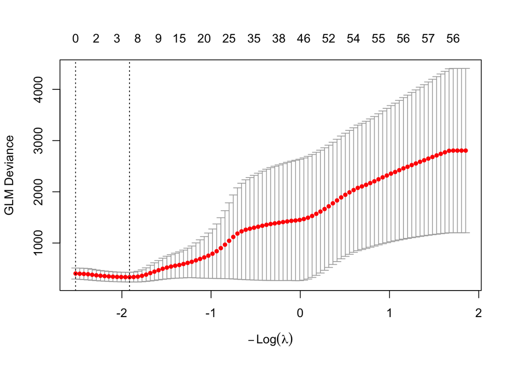

```r
######################
#### Early Fusion ####
######################

## Cross-validation for Early Fusion
cvfit_mv_early <- multiview::cv.multiview(
  x_list = xList_train,
  y = y_train,
  rho = 0,
  alpha = 1,
  nfolds = 5
)

## Plot the cross-validation curve
plot(cvfit_mv_early)
```

```r
## Predict on the test set using CV-selected lambda
y_pred_mv_early <- predict(
  cvfit_mv_early,
  newx = xList_test,
  s = "lambda.min"
)

## Mean squared prediction error
mspe_mv_early <- mean((y_pred_mv_early - y_test)^2)
print(mspe_mv_early)
```

```
#> [1] 830.9185
```

```r
## Extract coefficients at lambda.min
coefs_mv_early <- coef(
  cvfit_mv_early,
  s = "lambda.min"
)

## Number of selected features, excluding intercept
n_nonzero_mv_early <- sum(coefs_mv_early != 0) - 1
print(n_nonzero_mv_early)
```

```
#> [1] 7
```

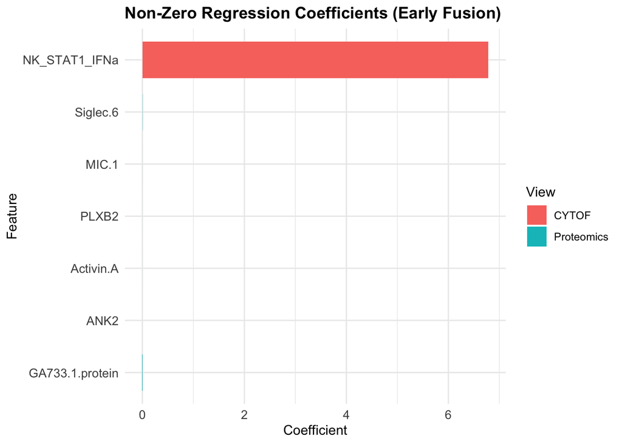

```r
###############################################
#### Plot Selected Features: Early Fusion ####
###############################################

## Convert coefficients into a dataframe
nonzero_coef_mv_early <- data.frame(
  feature = rownames(coefs_mv_early),
  coefficient = as.numeric(coefs_mv_early)
)

## Remove intercept and zero coefficients
nonzero_coef_mv_early <- nonzero_coef_mv_early %>%
  filter(
    feature != "(Intercept)",
    coefficient != 0
  )

## Add the corresponding data view
nonzero_coef_mv_early$view <- pcl_train$feature_metadata$featureType[
  match(
    nonzero_coef_mv_early$feature,
    pcl_train$feature_metadata$featureID
  )
]

## Reorder features according to coefficient value
nonzero_coef_mv_early$feature <- fct_reorder(
  nonzero_coef_mv_early$feature,
  nonzero_coef_mv_early$coefficient
)

## Plot
p1 <- ggplot(
  nonzero_coef_mv_early,
  aes(
    x = feature,
    y = coefficient,
    fill = view
  )
) +
  geom_col(width = 0.7) +
  labs(
    title = "Non-Zero Regression Coefficients (Early Fusion)",
    x = "Feature",
    y = "Coefficient",
    fill = "View"
  ) +
  coord_flip() +
  theme_minimal() +
  theme(
    axis.text = element_text(size = 10),
    plot.title = element_text(face = "bold")
  )

print(p1)
```

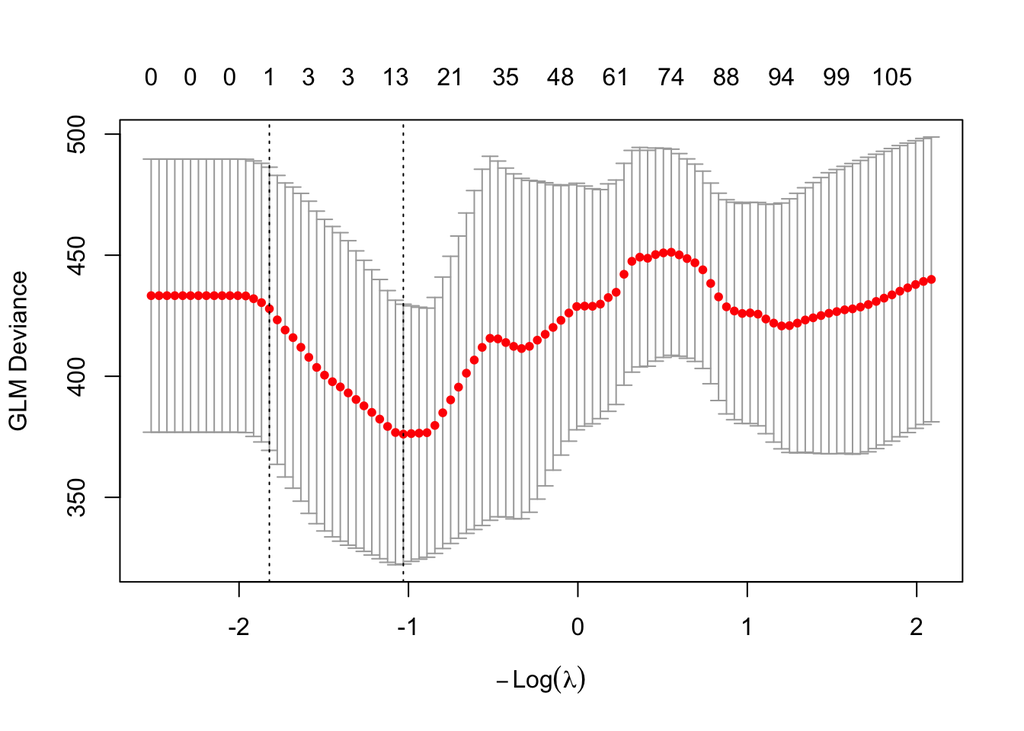

```r
#####################
#### Late Fusion ####
#####################

## Cross-validation for Late Fusion
cvfit_mv_late <- multiview::cv.multiview(
  x_list = xList_train,
  y = y_train,
  rho = 1,
  alpha = 1,
  nfolds = 5
)

## Plot the cross-validation curve
plot(cvfit_mv_late)
```

```r
## Predict on the test set using CV-selected lambda
y_pred_mv_late <- predict(
  cvfit_mv_late,
  newx = xList_test,
  s = "lambda.min"
)

## Mean squared prediction error
mspe_mv_late <- mean((y_pred_mv_late - y_test)^2)
print(mspe_mv_late)
```

```
#> [1] 917.9709
```

```r
## Extract coefficients at lambda.min
coefs_mv_late <- coef(
  cvfit_mv_late,
  s = "lambda.min"
)

## Number of selected features, excluding intercept
n_nonzero_mv_late <- sum(coefs_mv_late != 0) - 1
print(n_nonzero_mv_late)
```

```
#> [1] 14
```

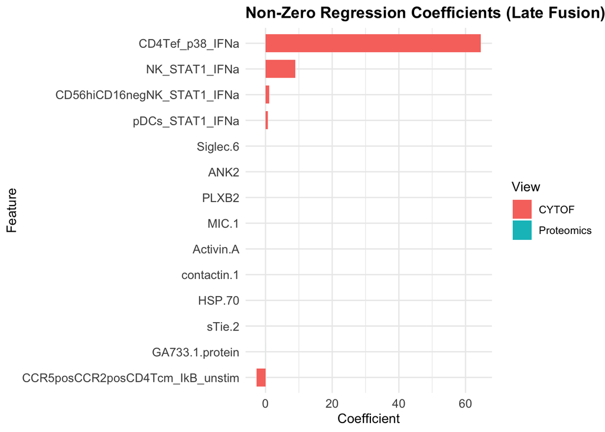

```r
###############################################
##### Plot Selected Features: Late Fusion #####
###############################################

## Convert coefficients into a dataframe
nonzero_coef_mv_late <- data.frame(
  feature = rownames(coefs_mv_late),
  coefficient = as.numeric(coefs_mv_late)
)

## Remove intercept and zero coefficients
nonzero_coef_mv_late <- nonzero_coef_mv_late %>%
  filter(
    feature != "(Intercept)",
    coefficient != 0
  )

## Add the corresponding data view
nonzero_coef_mv_late$view <- pcl_train$feature_metadata$featureType[
  match(
    nonzero_coef_mv_late$feature,
    pcl_train$feature_metadata$featureID
  )
]

## Reorder features according to coefficient value
nonzero_coef_mv_late$feature <- fct_reorder(
  nonzero_coef_mv_late$feature,
  nonzero_coef_mv_late$coefficient
)

## Plot
p2 <- ggplot(
  nonzero_coef_mv_late,
  aes(
    x = feature,
    y = coefficient,
    fill = view
  )
) +
  geom_col(width = 0.7) +
  labs(
    title = "Non-Zero Regression Coefficients (Late Fusion)",
    x = "Feature",
    y = "Coefficient",
    fill = "View"
  ) +
  coord_flip() +
  theme_minimal() +
  theme(
    axis.text = element_text(size = 10),
    plot.title = element_text(face = "bold")
  )

print(p2)
```

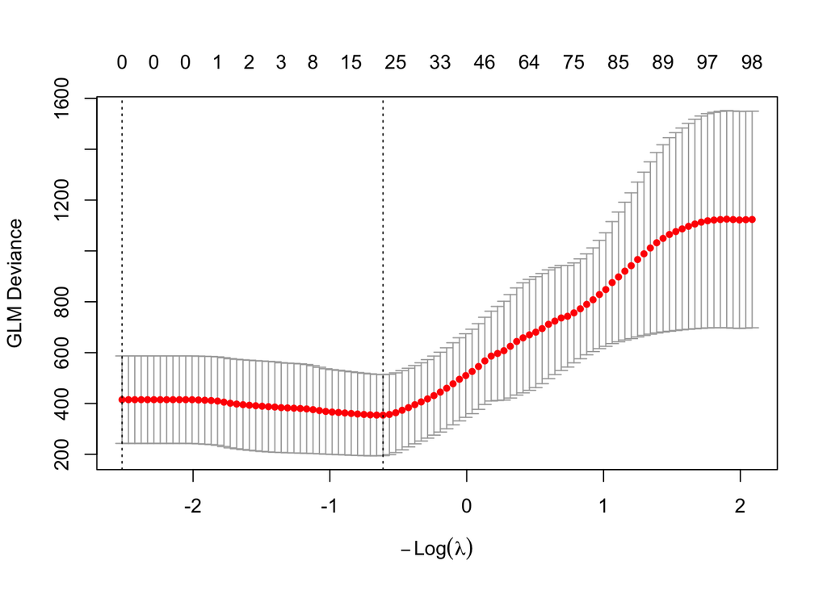

```r
#############################
#### Intermediate Fusion ####
#############################

## Cross-validation for Early Fusion
cvfit_mv_intermediate <- multiview::cv.multiview(
  x_list = xList_train,
  y = y_train,
  rho = 0.5,
  alpha = 1,
  nfolds = 5
)

## Plot the cross-validation curve
plot(cvfit_mv_intermediate)
```

```r
## Predict on the test set using CV-selected lambda
y_pred_mv_intermediate <- predict(
  cvfit_mv_intermediate,
  newx = xList_test,
  s = "lambda.min"
)

## Mean squared prediction error
mspe_mv_intermediate <- mean((y_pred_mv_intermediate - y_test)^2)
print(mspe_mv_intermediate)
```

```
#> [1] 770.136
```

```r
## Extract coefficients at lambda.min
coefs_mv_intermediate <- coef(
  cvfit_mv_intermediate,
  s = "lambda.min"
)

## Number of selected features, excluding intercept
n_nonzero_mv_intermediate <- sum(coefs_mv_intermediate != 0) - 1
print(n_nonzero_mv_intermediate)
```

```
#> [1] 21
```

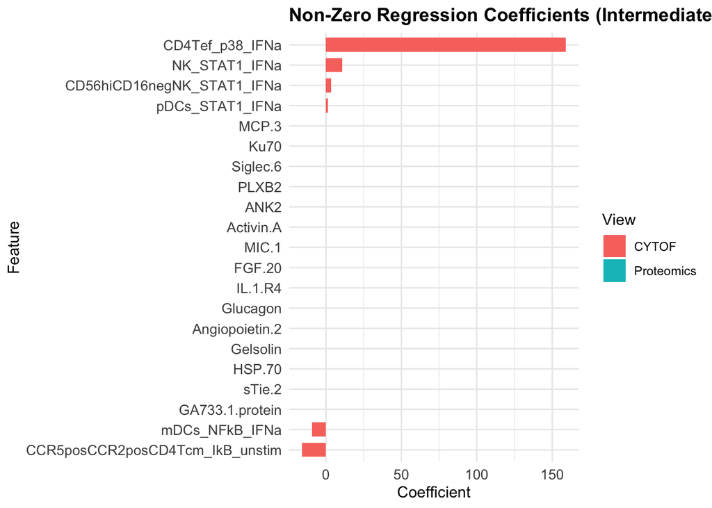

```r
#####################################################
#### Plot Selected Features: Intermediate Fusion ####
#####################################################

## Convert coefficients into a dataframe
nonzero_coef_mv_intermediate <- data.frame(
  feature = rownames(coefs_mv_intermediate),
  coefficient = as.numeric(coefs_mv_intermediate)
)

## Remove intercept and zero coefficients
nonzero_coef_mv_intermediate <- nonzero_coef_mv_intermediate %>%
  filter(
    feature != "(Intercept)",
    coefficient != 0
  )

## Add the corresponding data view
nonzero_coef_mv_intermediate$view <- pcl_train$feature_metadata$featureType[
  match(
    nonzero_coef_mv_intermediate$feature,
    pcl_train$feature_metadata$featureID
  )
]

## Reorder features according to coefficient value
nonzero_coef_mv_intermediate$feature <- fct_reorder(
  nonzero_coef_mv_intermediate$feature,
  nonzero_coef_mv_intermediate$coefficient
)

## Plot
p1 <- ggplot(
  nonzero_coef_mv_intermediate,
  aes(
    x = feature,
    y = coefficient,
    fill = view
  )
) +
  geom_col(width = 0.7) +
  labs(
    title = "Non-Zero Regression Coefficients (Intermediate Fusion)",
    x = "Feature",
    y = "Coefficient",
    fill = "View"
  ) +
  coord_flip() +
  theme_minimal() +
  theme(
    axis.text = element_text(size = 10),
    plot.title = element_text(face = "bold")
  )

print(p1)
```

# 5 Integrated Learner using `IntegratedLearner` R Package

`IntegratedLearner` late fusion algorithm proceeds by 1) fitting a machine learning algorithm per-layer to predict outcome (`base_learner`) and 2) combining the layer-wise cross-validated predictions using a meta model (`meta_learner`) to generate final predictions based on all available data points. As a default choice, we recommend `SL.nnls.auc` as the meta model algorithm. It fits a non-negative least squares (in case of continuous outcome) and rank loss minimization (in case of binary outcome) on layer-wise cross-validated predictions to generate the final predictions and quantify per-layer contribution in the final predictions. For further details, see [preprint](https://pubmed.ncbi.nlm.nih.gov/38146838/).

The default base model recommendation for `IntegratedLearner` is Bayesian additive regression trees or BART (`base_learner='SL.BART'`). Using BART as base-model yields uncertainty estimates (i.e. credible intervals) of the prediction and model parameters in addition to reporting a small set of interpretable features for follow-up experiments (i.e. feature importance scores).

Below we briefly describe the main arguments controlling model fitting and integration in `IntegratedLearner()`:

```r
###############################
#### Fit IntegratedLearner ####
###############################

## Fit IntegratedLearner using the PCL pipeline
fit_IntegratedLearner <- IntegratedLearner(
  PCL_train = pcl_train,
  PCL_valid = pcl_valid,
  outcome_col = "Y",
  subject_id_col = "subjectID",
  folds = 5,
  seed = 123,
  base_learner = "SL.BART",
  meta_learner = "SL.nnls.auc",
  run_screening = FALSE,
  run_concat = TRUE,
  run_stacked = TRUE,
  verbose = FALSE,
  print_learner = FALSE,
  family = gaussian()
)

## Prediction values of Y for both early and late fusion schemes
y_pred_early <- fit_IntegratedLearner$yhat.test$concatenated
y_pred_late <- fit_IntegratedLearner$yhat.test$stacked

## Calculation of mean squared prediction error
mspe_IL_early <- mean((y_pred_early - pcl_valid$sample_metadata$Y)^2)
print(mspe_IL_early)
```

```
#> [1] 985.2016
```

```r
mspe_IL_late <- mean((y_pred_late - pcl_valid$sample_metadata$Y)^2)
print(mspe_IL_late)
```

```
#> [1] 674.7659
```

Because the early-fusion IntegratedLearner model uses BART rather than a linear regression model, it does not produce regression coefficients analogous to those obtained from multiview or BayesCOOP. Instead, we examine signed feature importance from the concatenated BART model. The following plot shows the 20 features with the largest absolute signed importance values and identifies the data modality associated with each feature.

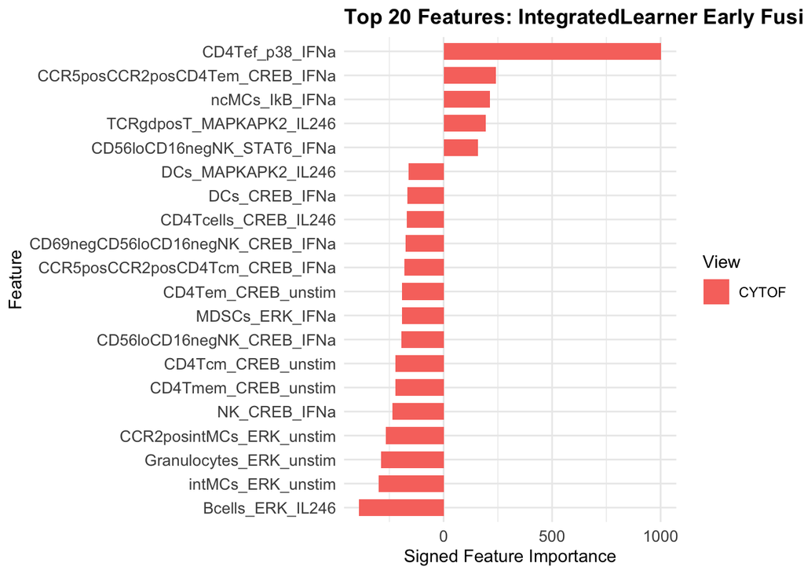

```r
######################################################
#### IntegratedLearner: Early Fusion Importance ######
######################################################

## Extract signed feature importance for early fusion
importance_IL_early <-
  fit_IntegratedLearner$feature_importance_signed

## Convert into a dataframe
df_IL_early <- data.frame(
  feature = names(importance_IL_early),
  importance = as.numeric(importance_IL_early)
)

## Remove features with zero importance
df_IL_early <- df_IL_early %>%
  filter(importance != 0)

## Add the corresponding data view
df_IL_early$view <-
  pcl_train$feature_metadata$featureType[
    match(
      df_IL_early$feature,
      pcl_train$feature_metadata$featureID
    )
  ]

## Select top 20 features by absolute importance
df_IL_early_top <- df_IL_early %>%
  mutate(
    abs_importance = abs(importance)
  ) %>%
  arrange(
    desc(abs_importance)
  ) %>%
  slice_head(n = 20)

## Reorder features according to signed importance
df_IL_early_top$feature <- fct_reorder(
  df_IL_early_top$feature,
  df_IL_early_top$importance
)

## Plot
p_IL_early <- ggplot(
  df_IL_early_top,
  aes(
    x = feature,
    y = importance,
    fill = view
  )
) +
  geom_col(width = 0.7) +
  labs(
    title = "Top 20 Features: IntegratedLearner Early Fusion",
    x = "Feature",
    y = "Signed Feature Importance",
    fill = "View"
  ) +
  coord_flip() +
  theme_minimal() +
  theme(
    axis.text = element_text(size = 10),
    plot.title = element_text(face = "bold")
  )

print(p_IL_early)
```

# 6 Bayesian Cooperative Learning using `BayesCOOP` R Package

While the `multiview` package implements cooperative learning by combining prediction loss with an agreement penalty across multiple views, it does **not inherently provide uncertainty quantification (UQ)** for the fitted models or predictions. In many scientific applications, especially those involving high stakes or interpretation of effect sizes, simply reporting point estimates and predictive accuracy is not sufficient; one often also needs credible intervals, posterior distributions, or measures of confidence to assess the reliability of findings.

`BayesCOOP` addresses this gap by placing a **Bayesian group spike-and-slab double exponential (Laplace) prior** on the coefficients, which encourages both sparsity and view-specific feature selection in a principled probabilistic framework. It combines fast maximum a posteriori (MAP) estimation with a **Bayesian Bootstrap** to approximate posterior sampling and enable scalable uncertainty estimation for both model parameters and predictions. This allows users to obtain credible intervals, posterior summaries of view agreement parameters, and measures of uncertainty that reflect uncertainty in the data and model fit, rather than only point estimates.

Because of this Bayesian formulation, `BayesCOOP` not only selects relevant features and captures cooperative effects across views but also facilitates rigorous uncertainty quantification, which is important for interpretation and for downstream decision-making in applications where confidence in predictions matters. For further details, please refer to the [preprint](https://www.biorxiv.org/content/10.1101/2025.10.23.684056v1).

## 6.1 Fit `BayesCOOP` (Bayesian Bootstrap Enabled)

Here we fit BayesCOOP using `bb = TRUE` to enable Bayesian Bootstrap–based uncertainty estimation. This step may take a while because it involves multiple bootstrap iterations, which can be adjusted through the `bbiters` and `bbburn` parameters. The output includes the posterior samples of the parameters and runtime.

```r
set.seed(123)

## Fitting BayesCOOP
fit_BayesCOOP_bb_true <- BayesCOOP::BayesCOOP(data_train = pcl_train,
  family = "gaussian",
  ss = c(0.05, 1),
  group = TRUE,
  bb = TRUE,
  alpha_dirich = 1,
  bbiters = 1100,
  bbburn = 100,
  maxit = 100,
  warning = TRUE,
  verbose = FALSE,
  control = list()
)
```

## 6.2 Fit `BayesCOOP` (Bayesian Bootstrap Disabled)

```r
set.seed(123)

## Fitting BayesCOOP with `bb` = FALSE
fit_BayesCOOP_bb_false <- BayesCOOP::BayesCOOP(
  data_train = pcl_train,
  family = "gaussian",
  ss = c(0.05, 1),
  group = TRUE,
  bb = FALSE,
  alpha_dirich = 1,
  bbiters = 1100,
  bbburn = 100,
  maxit = 100,
  warning = TRUE,
  verbose = FALSE,
  control = list(rho = 0.5)
)
```

```
#> EM Coordinate Decent Iterations: 6
#> Computational time: 0.001 minutes
#> EM Coordinate Decent Iterations: 15
#> Computational time: 0.002 minutes
```

```r
## Prediction
pred_BayesCOOP_bb_false <- predict(object = fit_BayesCOOP_bb_false,
                                            newdata = pcl_valid, family = "gaussian",
                                            bb = FALSE, warning = TRUE, verbose = TRUE)

## Calculating mean squared prediction error
mspe_BayesCOOP_bb_false <- mean((pred_BayesCOOP_bb_false$y_pred - pred_BayesCOOP_bb_false$y_valid) ^ 2)
print(mspe_BayesCOOP_bb_false)
```

```
#> [1] 349.9093
```

## 6.3 Prediction Performance

```r
## Prediction when bb is TRUE
pred_BayesCOOP_bb_true <- predict(object = fit_BayesCOOP_bb_true,
                                            newdata = pcl_valid, family = "gaussian",
                                            bb = TRUE, warning = TRUE, verbose = TRUE)

## Calculating mean squared prediction error when bb is TRUE
mspe_BayesCOOP_bb_true <- mean((pred_BayesCOOP_bb_true$y_pred - pred_BayesCOOP_bb_true$y_valid) ^ 2)
print(mspe_BayesCOOP_bb_true)
```

```
#> [1] 435.0642
```

```r
## Prediction when bb is FALSE
pred_BayesCOOP_bb_false <- predict(object = fit_BayesCOOP_bb_false,
                                            newdata = pcl_valid, family = "gaussian",
                                            bb = FALSE, warning = TRUE, verbose = TRUE)

## Calculating mean squared prediction error when bb is FALSE
mspe_BayesCOOP_bb_false <- mean((pred_BayesCOOP_bb_false$y_pred - pred_BayesCOOP_bb_false$y_valid) ^ 2)
print(mspe_BayesCOOP_bb_false)
```

```
#> [1] 349.9093
```

## 6.4 Feature Selection / Sparsity Comparison

We now count the number of **selected (nonzero) features** for each method to compare their **sparsity** and **selection aggressiveness**.

```r
## Number of features selected for BayesCOOP with `bb` = TRUE
n_nz_BayesCOOP_bb_true  <- sum(fit_BayesCOOP_bb_true$beta_postmed!=0)
## Number of features selected for BayesCOOP with `bb` = FALSE
n_nz_BayesCOOP_bb_false <- sum(fit_BayesCOOP_bb_false$beta_MAP!=0)
## Number of features selected for multiview
sparsity_table <- rbind(
  data.frame(method = "BayesCOOP (bb=TRUE)",  n_selected_feat = n_nz_BayesCOOP_bb_true),
  data.frame(method = "BayesCOOP (bb=FALSE)", n_selected_feat = n_nz_BayesCOOP_bb_false)
)

## Print table comparing the number of selected features for diff methods
sparsity_table
```

```
#>                 method n_selected_feat
#> 1  BayesCOOP (bb=TRUE)              19
#> 2 BayesCOOP (bb=FALSE)              57
```

Finally, we examine the features selected by `BayesCOOP`. For this tutorial, we focus on the results obtained with `bb = TRUE`, since this setting provides uncertainty quantification in addition to point estimates, allowing us to assess both feature selection and associated variability.

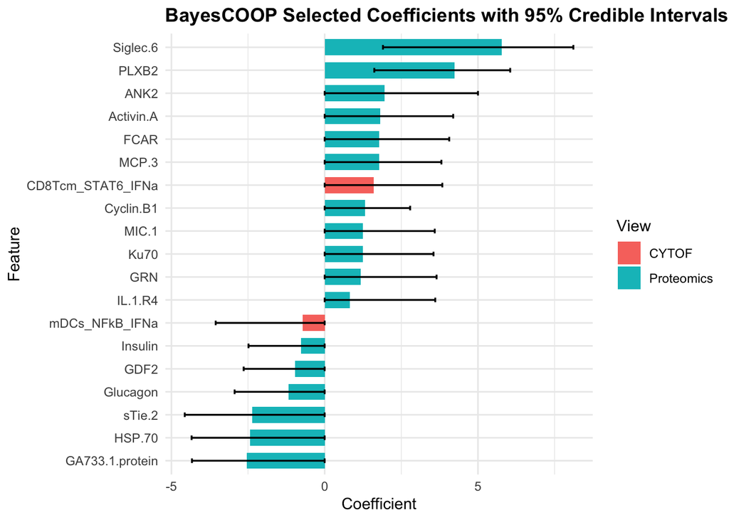

```r
# Posterior medians (already extracted)
beta_postmed <- fit_BayesCOOP_bb_true$beta_postmed
nonzero_pos  <- which(beta_postmed != 0)

coef_est <- beta_postmed[nonzero_pos]

# Posterior samples for selected coefficients
beta_postsamp <- fit_BayesCOOP_bb_true$beta_samples
postsamp_sel  <- beta_postsamp[, nonzero_pos]

# Compute credible intervals
q1 <- apply(postsamp_sel, 2, quantile, 0.025)
q3 <- apply(postsamp_sel, 2, quantile, 0.975)

# Create tidy dataframe
df_BayesCOOP <- data.frame(
  feature     = names(coef_est),
  coefficient = coef_est,
  q1          = q1,
  q3          = q3
)

df_BayesCOOP <- df_BayesCOOP %>%
  mutate(
    view = pcl_train$feature_metadata$featureType[
      match(feature, pcl_train$feature_metadata$featureID)
    ]
  ) %>%
  arrange(view, coefficient) %>%                         # optional: group ordering by view
  mutate(feature = fct_reorder(feature, coefficient))     # order bars by coefficient

p4 <- ggplot(df_BayesCOOP,
             aes(x = feature, y = coefficient, fill = view)) +
  geom_col(width = 0.7) +
  geom_errorbar(aes(ymin = q1, ymax = q3),
                width = 0.2,
                color = "black",
                linewidth = 0.6) +
  coord_flip() +
  labs(
    title = "BayesCOOP Selected Coefficients with 95% Credible Intervals",
    x = "Feature",
    y = "Coefficient",
    fill = "View"
  ) +
  theme_minimal() +
  theme(
    plot.title = element_text(face = "bold")
  )


print(p4)
```

# 7 Factor Model Based Multiview Learning Approach using `jafar` R Package

`jafar` package implements two supervised Bayesian factor modeling approaches for multi-view data integration:

- **Joint Factor Regression ($\texttt{JFR}$):** a baseline model that captures the combined variation across multiple data views using a single set of latent factors.
- **Joint Additive Factor Regression ($\texttt{JAFAR}$):** a more refined model that explicitly decomposes variation into shared and view-specific components.

Isolating variation unique to each data modality – whether genuine signal or measurement artifact – can be particularly advantageous in high-dimensional settings, increasing interpretability and improving scalability. $\texttt{JAFAR}$ ensures correct separation of the additive component by placing zero prior mass on configurations with ill-posed allocation of specific factors into the shared component.

Both models leverage extensions of the $\texttt{CUSP}$ prior [(Legramanti et al., 2020)](http://academic.oup.com/biomet/article/107/3/745/5847840), learning adaptively the number of factors in a fully Bayesian way. The package implements independent $\texttt{CUSP}$ priors ($\texttt{I-CUSP}$) for $\texttt{JFR}$ and dependent $\texttt{CUSP}$ priors ($\texttt{D-CUSP}$) for $\texttt{JAFAR}$.

In this module, we focus on $\texttt{JAFAR}$ for ease of exposition. Using $\texttt{JFR}$ is completely analogous, simply replacing the function `gibbs_jafar()` with `gibbs_jfr()`$.

## 7.1 Preprocess the Data for `jafar` Implementation

```r
## Calculate the number of views
views <- unique(pcl_train$feature_metadata$featureType)
m <- length(views)

## pre-processing for jafar
y <- pcl_train$sample_metadata$Y
yTest <- pcl_valid$sample_metadata$Y

## Scaling the predictors for bmlasso
X_process <- lapply(xList_train, function(foo) as.matrix(scale(foo)))
X_process_test <- lapply(xList_test, function(foo) as.matrix(scale(foo)))

## centering the response
y_process <- y - mean(y)
y_process_test <- yTest - mean(yTest)
```

## 7.2 Run `jafar`

```r
## Initialize Markov Chain Monte Carlo(MCMC) parameters for jafar
tMCMC = 5000 #10000
tBurnIn = 2000 #5000
tThin = 1
mcmc_seed=123
K0 = 5 #25
K0_m = rep(5, m)#rep(20,m)

## Jafar Implementation
mcmc_supervised <- gibbs_jafar(X_process, y=y_process, K0=K0, K0_m=K0_m,
                               tMCMC=tMCMC, tBurnIn=tBurnIn, tThin=tThin,
                               hyperparams = list(seed = mcmc_seed))
```

```
#> [1] "Running supervised jafar under d-cusp prior"
#>           [  0%] K=05 K1=05 K2=05
#>           [ 10%] K=05 K1=05 K2=05
#>           [ 20%] K=05 K1=05 K2=05
#>           [ 30%] K=05 K1=05 K2=05
#>           [ 40%] K=05 K1=05 K2=05
#>           [ 50%] K=05 K1=05 K2=05
#>           [ 60%] K=05 K1=05 K2=05
#>           [ 70%] K=05 K1=05 K2=05
#>           [ 80%] K=05 K1=05 K2=05
#>           [ 90%] K=05 K1=05 K2=05
#>           [100%] K=05 K1=05 K2=05
```

## 7.3 Prediction Performance

We can then compute response predictions and assess predictive performance. Expected values and other distributional properties of $y_i \mid \{X_{m i}\}_m$ can be easily obtained leveraging the latent representation
$$\mathbb{E}[\,y_i \mid \{X_{m i}\}_m \,]
= \mathbb{E}\big[\, \mathbb{E}[\,y_i \mid \eta_i, \{\phi_{m i}\}_m \,]
\mid \{X_{m i}\}_m \big]$$
This holds both for in-sample and out-of-sample observations.

```r
## Prediction and mspe for jafar implemenation
y_pred <- predict_y(X_process_test, mcmc_supervised)
```

```
#> [1] " - Computing Response Predictions - "
#> [1] "         [  0%]"
#> [1] "         [ 10%]"
#> [1] "         [ 20%]"
#> [1] "         [ 30%]"
#> [1] "         [ 40%]"
#> [1] "         [ 50%]"
#> [1] "         [ 60%]"
#> [1] "         [ 70%]"
#> [1] "         [ 80%]"
#> [1] "         [ 90%]"
#> [1] "         [100%]"
```

```r
mspe_jafar <- mean((colMeans(y_pred$mean) - y_process_test)^2)
print(mspe_jafar)
```

```
#> [1] 614.5557
```

# 8 Predictive Performance Comparison (MSPE) across different methods

The plot below summarizes the mean squared prediction error (MSPE) across all methods evaluated in this module for the StelzerDOS continuous outcome dataset. Lower MSPE indicates better predictive accuracy on the held-out test set.

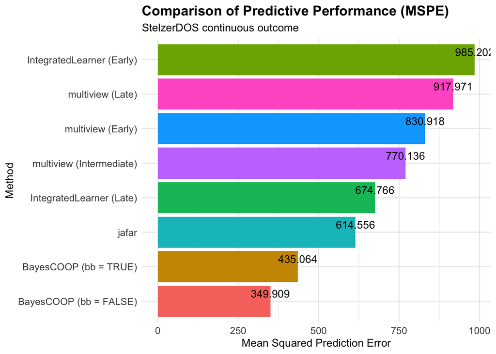

```r
# Compile all MSPEs into one tidy dataframe
mspe_all <- tibble(
  Method = c(
    "multiview (Early)",
    "multiview (Intermediate)",
    "multiview (Late)",
    "IntegratedLearner (Early)",
    "IntegratedLearner (Late)",
    "BayesCOOP (bb = TRUE)",
    "BayesCOOP (bb = FALSE)",
    "jafar"
  ),
  MSPE = c(
    mspe_mv_early,
    mspe_mv_intermediate,
    mspe_mv_late,
    mspe_IL_early,
    mspe_IL_late,
    mspe_BayesCOOP_bb_true,
    mspe_BayesCOOP_bb_false,
    mspe_jafar
  )
)

# Create the barplot
ggplot(mspe_all, aes(x = fct_reorder(Method, MSPE), y = MSPE, fill = Method)) +
  geom_col(show.legend = FALSE) +
  geom_text(aes(label = round(MSPE, 3)), vjust = -0.5) +
  coord_flip() +
  labs(
    title = "Comparison of Predictive Performance (MSPE)",
    subtitle = "StelzerDOS continuous outcome",
    x = "Method",
    y = "Mean Squared Prediction Error"
  ) +
  theme_minimal() +
  theme(
    axis.text = element_text(size = 10),
    plot.title = element_text(size = 14, face = "bold")
  )
```

# 9 Multimodal Conformal Inference using `Coracle` R Package

**Coracle** is a conformalized framework for multimodal AI with continuous outcomes that adapts to early, late, and intermediate fusion. It also provides theoretical marginal confidence guarantees and achieves valid finite-sample coverage without relying on distributional assumptions.

Here, we applied Coracle to a pregnancy dataset to produce finite-sample valid prediction intervals and compared its coverage behavior against prediction intervals using BART and BayesCOOP. The results illustrate how Coracle provides robust, distribution-free uncertainty quantification across fusion paradigms, particularly in settings where competing methods yield overly narrow intervals.

`Coracle` is installed by `setup/install.R` along with the other course packages, so we simply load it here.

```r
library(Coracle)
```

```r
###########################################################
#### Divide Training Data into Proper Train and Calib ####
###########################################################

## Coracle uses split conformal prediction.
## We divide the existing processed pcl_train object into:
##   1. proper training set: 75%
##   2. calibration set: 25%
##
## The existing pcl_valid object remains the independent
## external validation set.

set.seed(1234)

## Sample indices for the proper training set
train_elements <- sample(
  1:ncol(pcl_train$feature_table),
  size = floor(0.75 * ncol(pcl_train$feature_table)),
  replace = FALSE
)

## Construct proper training PCL object
data_train_coracle <- list(
  feature_table = pcl_train$feature_table[, train_elements, drop = FALSE],
  sample_metadata = pcl_train$sample_metadata[train_elements, , drop = FALSE],
  feature_metadata = pcl_train$feature_metadata
)

## Construct calibration PCL object
data_calib <- list(
  feature_table = pcl_train$feature_table[, -train_elements, drop = FALSE],
  sample_metadata = pcl_train$sample_metadata[-train_elements, , drop = FALSE],
  feature_metadata = pcl_train$feature_metadata
)

## Independent validation set
data_valid <- pcl_valid

## Check dimensions
print(dim(data_train_coracle$feature_table))
```

```
#> [1] 2193   39
```

```r
print(dim(data_calib$feature_table))
```

```
#> [1] 2193   14
```

```r
print(dim(data_valid$feature_table))
```

```
#> [1] 2193    8
```

```r
print(dim(data_train_coracle$sample_metadata))
```

```
#> [1] 39  2
```

```r
print(dim(data_calib$sample_metadata))
```

```
#> [1] 14  2
```

```r
print(dim(data_valid$sample_metadata))
```

```
#> [1] 8 2
```

```r
###########################################################
#### Fit Base Learners Required for Coracle ##############
###########################################################

## IntegratedLearner provides the base models for:
##   Early Fusion
##   Late Fusion
##
## BayesCOOP provides the base model for:
##   Intermediate Fusion


###########################################################
#### IntegratedLearner for Early and Late Fusion #########
###########################################################

fit_coracle_IL <- IntegratedLearner(
  PCL_train = data_train_coracle,
  PCL_valid = data_calib,
  outcome_col = "Y",
  subject_id_col = "subjectID",
  folds = 5,
  seed = 123,
  base_learner = "SL.BART",
  meta_learner = "SL.nnls.auc",
  run_concat = TRUE,
  run_stacked = TRUE,
  verbose = FALSE,
  print_learner = FALSE,
  refit.stack = TRUE,
  family = gaussian()
)


###########################################################
#### BayesCOOP for Intermediate Fusion ####################
###########################################################

fit_coracle_BayesCOOP <- BayesCOOP::BayesCOOP(
  data_train = data_train_coracle,
  bb = TRUE,
  alpha_dirich = 1,
  bbiters = 110,
  bbburn = 10,
  maxit = 100,
  control = list()
)
```

[output not shown]

[output cut: 165 more lines]

[output not shown]

```r
###########################################################
##################### RUN CORACLE #########################
###########################################################

conformal_pred <- Coracle::Coracle(
  fit = fit_coracle_IL,
  fit_coop = fit_coracle_BayesCOOP,
  data_calib = data_calib,
  data_valid = data_valid,
  fusion_choice = c("early", "intermediate", "late"),
  conf_level = 0.95
)

## Extract Coracle output dataframe
df_coracle <- conformal_pred$df

## View output
print(head(df_coracle))
```

```
#>   subjectID Y_true Y_pred(early)      Coracle(early) Coverage(early)
#> 1         4    -61     -79.55220 [-136.847, -22.258]               1
#> 2        15    -60     -78.62149 [-135.916, -21.327]               1
#> 3        47    -94     -80.76495 [-138.059, -23.471]               1
#> 4       101    -21     -76.63543  [-133.93, -19.341]               1
#> 5       104    -50     -75.89083 [-133.185, -18.596]               1
#> 6       105   -109     -83.80996 [-141.104, -26.516]               1
#>   Y_pred(late)       Coracle(late) Coverage(late) Y_pred(intermediate)
#> 1    -76.76028 [-136.509, -17.011]              1            -72.74648
#> 2    -77.01395 [-136.763, -17.265]              1            -58.35499
#> 3    -78.03177 [-137.781, -18.283]              1            -59.52553
#> 4    -74.47404 [-134.223, -14.725]              1            -49.42827
#> 5    -74.14192 [-133.891, -14.393]              1            -54.11199
#> 6    -82.01702 [-141.766, -22.268]              1            -76.62942
#>   Coracle(intermediate) Coverage(intermediate)
#> 1    [-117.753, -27.74]                      1
#> 2   [-103.361, -13.348]                      1
#> 3   [-104.532, -14.519]                      1
#> 4     [-94.435, -4.422]                      1
#> 5     [-99.118, -9.105]                      1
#> 6   [-121.636, -31.623]                      1
```

```r
## View empirical coverage
print(conformal_pred$coverage)
```

```
#> $`Coracle(early)`
#> [1] 1
#>
#> $`Coracle(late)`
#> [1] 1
#>
#> $`Coracle(intermediate)`
#> [1] 1
```

```r
###########################################################
#### Extract Coracle Prediction Interval Bounds ##########
###########################################################

## Early Fusion
Coracle_early_lower <- sapply(
  df_coracle[["Coracle(early)"]],
  function(x) Coracle:::parse_interval(x)[1]
)

Coracle_early_upper <- sapply(
  df_coracle[["Coracle(early)"]],
  function(x) Coracle:::parse_interval(x)[2]
)

## Intermediate Fusion
Coracle_intermediate_lower <- sapply(
  df_coracle[["Coracle(intermediate)"]],
  function(x) Coracle:::parse_interval(x)[1]
)

Coracle_intermediate_upper <- sapply(
  df_coracle[["Coracle(intermediate)"]],
  function(x) Coracle:::parse_interval(x)[2]
)

## Late Fusion
Coracle_late_lower <- sapply(
  df_coracle[["Coracle(late)"]],
  function(x) Coracle:::parse_interval(x)[1]
)

Coracle_late_upper <- sapply(
  df_coracle[["Coracle(late)"]],
  function(x) Coracle:::parse_interval(x)[2]
)


###########################################################
#### Comparison with BART Prediction Intervals ###########
###########################################################

## Fit IntegratedLearner using:
##   proper training data for fitting
##   independent validation data for prediction

fit_bart <- IntegratedLearner(
  PCL_train = data_train_coracle,
  PCL_valid = data_valid,
  outcome_col = "Y",
  subject_id_col = "subjectID",
  folds = 5,
  seed = 123,
  base_learner = "SL.BART",
  meta_learner = "SL.nnls.auc",
  run_concat = TRUE,
  run_stacked = TRUE,
  verbose = FALSE,
  print_learner = FALSE,
  refit.stack = TRUE,
  family = gaussian()
)


###########################################################
#### BART Posterior Samples: Early Fusion #################
###########################################################

## Extract fitted SuperLearner object
SL_fit_concat_BART <- fit_bart$SL_fits$SL_fit_concat

## Extract the fitted BART model
model_concat <- SL_fit_concat_BART$fitLibrary[[1]]$object

## Obtain posterior predictive samples
post_samples_concat <- bart_machine_get_posterior(
  model_concat,
  as.data.frame(t(data_valid$feature_table))
)$y_hat_posterior_samples


###########################################################
#### Construct View-Specific Validation Matrices #########
###########################################################

## Create list of validation matrices:
## samples x features for each view

dataList_valid <- lapply(
  views,
  function(view_i) {
    feature_ids <- rownames(data_valid$feature_metadata)[
      data_valid$feature_metadata$featureType == view_i
    ]

    as.data.frame(
      t(
        data_valid$feature_table[
          feature_ids,
          ,
          drop = FALSE
        ]
      )
    )
  }
)

## Assign view names
names(dataList_valid) <- views


###########################################################
#### BART Posterior Samples: Late Fusion ##################
###########################################################

## Extract late-fusion weights
weights <- fit_bart$weights

## Create storage for posterior samples
post_samples_stacked <- vector("list", length(weights))
names(post_samples_stacked) <- names(weights)

## Obtain posterior samples from each fitted layer
for (i in seq_along(post_samples_stacked)) {
  post_samples_stacked[[i]] <- bart_machine_get_posterior(
    fit_bart$model_fits$model_layers[[i]],
    dataList_valid[[i]]
  )$y_hat_posterior_samples
}

## Combine posterior samples using stacking weights
post_samples_stacked <- Reduce(
  "+",
  Map("*", post_samples_stacked, weights)
)


###########################################################
#### Construct BART Prediction Intervals ##################
###########################################################

## Early Fusion BART intervals
BART_early_interval <- t(
  apply(
    post_samples_concat,
    1,
    quantile,
    probs = c(0.025, 0.975)
  )
)

BART_early_lower <- as.vector(BART_early_interval[, 1])
BART_early_upper <- as.vector(BART_early_interval[, 2])

## Late Fusion BART intervals
BART_late_interval <- t(
  apply(
    post_samples_stacked,
    1,
    quantile,
    probs = c(0.025, 0.975)
  )
)

BART_late_lower <- as.vector(BART_late_interval[, 1])
BART_late_upper <- as.vector(BART_late_interval[, 2])


###########################################################
#### Comparison with BayesCOOP Prediction Intervals ######
###########################################################

## Fit BayesCOOP using the same proper training data
fit_bcoop_compare <- fit_coracle_BayesCOOP

## Predict on independent validation data
predict_bcoop <- predict(
  fit_bcoop_compare,
  newdata = data_valid,
  family = "gaussian",
  bb = TRUE,
  warning = TRUE,
  verbose = FALSE
)

## Construct BayesCOOP lower bound
BayesCOOP_lower <- apply(
  predict_bcoop$y_samples + mean(predict_bcoop$y_valid),
  2,
  quantile,
  probs = 0.025
)

## Construct BayesCOOP upper bound
BayesCOOP_upper <- apply(
  predict_bcoop$y_samples + mean(predict_bcoop$y_valid),
  2,
  quantile,
  probs = 0.975
)


###########################################################
#### Combine All Prediction Intervals #####################
###########################################################

df_interval <- data.frame(
  Subjects = df_coracle$subjectID,
  TrueY = data_valid$sample_metadata$Y,

  ## Coracle Early
  Coracle_early_lower = Coracle_early_lower,
  Coracle_early_upper = Coracle_early_upper,

  ## Coracle Intermediate
  Coracle_intermediate_lower = Coracle_intermediate_lower,
  Coracle_intermediate_upper = Coracle_intermediate_upper,

  ## Coracle Late
  Coracle_late_lower = Coracle_late_lower,
  Coracle_late_upper = Coracle_late_upper,

  ## BayesCOOP
  BayesCOOP_lower = BayesCOOP_lower,
  BayesCOOP_upper = BayesCOOP_upper,

  ## BART Early
  BART_early_lower = BART_early_lower,
  BART_early_upper = BART_early_upper,

  ## BART Late
  BART_late_lower = BART_late_lower,
  BART_late_upper = BART_late_upper
)

## Reset row names
rownames(df_interval) <- 1:nrow(df_interval)
```

```r
###########################################################
#### Determine Whether True Value is Inside Intervals ####
###########################################################

## Coracle Early
inside_Coracle_early <- with(
  df_interval,
  TrueY >= Coracle_early_lower &
    TrueY <= Coracle_early_upper
)

## Coracle Intermediate
inside_Coracle_intermediate <- with(
  df_interval,
  TrueY >= Coracle_intermediate_lower &
    TrueY <= Coracle_intermediate_upper
)

## Coracle Late
inside_Coracle_late <- with(
  df_interval,
  TrueY >= Coracle_late_lower &
    TrueY <= Coracle_late_upper
)

## BART Early
inside_BART_early <- with(
  df_interval,
  TrueY >= BART_early_lower &
    TrueY <= BART_early_upper
)

## BART Late
inside_BART_late <- with(
  df_interval,
  TrueY >= BART_late_lower &
    TrueY <= BART_late_upper
)

## BayesCOOP
inside_BayesCOOP <- with(
  df_interval,
  TrueY >= BayesCOOP_lower &
    TrueY <= BayesCOOP_upper
)


###########################################################
#### Identify Special Coverage Cases ######################
###########################################################

## Covered by at least one Coracle strategy
## but missed by at least one non-conformal comparator

df_interval$mark <- (
  inside_Coracle_early |
    inside_Coracle_intermediate |
    inside_Coracle_late
) & (
  !inside_BART_early |
    !inside_BART_late |
    !inside_BayesCOOP
)

## Covered by every method
df_interval$all <- (
  inside_Coracle_early &
    inside_Coracle_intermediate &
    inside_Coracle_late &
    inside_BART_early &
    inside_BART_late &
    inside_BayesCOOP
)


###########################################################
#### Create Coverage Status Variable ######################
###########################################################

df_interval$true_status <- "Other"

## Consensus
df_interval$true_status[df_interval$all] <- "Consensus"

## Coracle supported
df_interval$true_status[df_interval$mark] <- "Coracle-supported"

## Convert to factor
df_interval$true_status <- factor(
  df_interval$true_status,
  levels = c(
    "Consensus",
    "Coracle-supported",
    "Other"
  )
)


###########################################################
#### Visualization of Prediction Intervals ###############
###########################################################

p_coracle <- ggplot(
  df_interval,
  aes(x = factor(Subjects))
) +

  #########################################################
## Coracle Early
#########################################################

geom_errorbar(
  aes(
    ymin = Coracle_early_lower,
    ymax = Coracle_early_upper,
    color = "Coracle (Early)"
  ),
  width = 0.2,
  position = position_nudge(x = -0.25)
) +

  #########################################################
## Coracle Late
#########################################################

geom_errorbar(
  aes(
    ymin = Coracle_late_lower,
    ymax = Coracle_late_upper,
    color = "Coracle (Late)"
  ),
  width = 0.2,
  position = position_nudge(x = -0.15)
) +

  #########################################################
## Coracle Intermediate
#########################################################

geom_errorbar(
  aes(
    ymin = Coracle_intermediate_lower,
    ymax = Coracle_intermediate_upper,
    color = "Coracle (Intermediate)"
  ),
  width = 0.2,
  position = position_nudge(x = -0.05)
) +

  #########################################################
## BART Early
#########################################################

geom_errorbar(
  aes(
    ymin = BART_early_lower,
    ymax = BART_early_upper,
    color = "IL BART (Early)"
  ),
  width = 0.2,
  position = position_nudge(x = 0.05)
) +

  #########################################################
## BayesCOOP Intermediate
#########################################################

geom_errorbar(
  aes(
    ymin = BayesCOOP_lower,
    ymax = BayesCOOP_upper,
    color = "BayesCOOP (Intermediate)"
  ),
  width = 0.2,
  position = position_nudge(x = 0.15)
) +

  #########################################################
## BART Late
#########################################################

geom_errorbar(
  aes(
    ymin = BART_late_lower,
    ymax = BART_late_upper,
    color = "IL BART (Late)"
  ),
  width = 0.2,
  position = position_nudge(x = 0.25)
) +

  #########################################################
## True Outcome Values
#########################################################

geom_point(
  aes(
    y = TrueY,
    fill = true_status
  ),
  shape = 22,
  size = 3.5,
  color = "black",
  stroke = 0.3
) +

  #########################################################
## Interval Colors
#########################################################

scale_color_manual(
  name = "Intervals",
  breaks = c(
    "IL BART (Early)",
    "IL BART (Late)",
    "BayesCOOP (Intermediate)",
    "Coracle (Early)",
    "Coracle (Intermediate)",
    "Coracle (Late)"
  ),
  values = c(
    "IL BART (Early)" = "#D41159",
    "IL BART (Late)" = "#009E73",
    "BayesCOOP (Intermediate)" = "#E1BE6A",
    "Coracle (Early)" = "#56B4E9",
    "Coracle (Intermediate)" = "#CC79A7",
    "Coracle (Late)" = "#FFA107"
  )
) +

  #########################################################
## True Value Coverage Status Colors
#########################################################

scale_fill_manual(
  name = "True value covered by",
  values = c(
    "Consensus" = "red",
    "Coracle-supported" = "blue",
    "Other" = "grey"
  ),
  labels = c(
    "Consensus (all methods)",
    paste0(
      "Covered by Coracle and missed by\n",
      "at least one non-conformal method"
    ),
    "Other"
  )
) +

  #########################################################
## Legend Ordering
#########################################################

guides(
  color = guide_legend(order = 1),
  fill = guide_legend(order = 2)
) +

  #########################################################
## Labels
#########################################################

labs(
  title = "Comparison of Prediction Intervals for StelzerDOS",
  x = "Subjects",
  y = "Predicted Labor Onset"
) +
```

[figure not shown]

```r
  #########################################################
## Theme
#########################################################

theme_classic() +

  theme(
    axis.text.x = element_blank(),
    axis.ticks.x = element_blank(),
    legend.position = "right",
    plot.title = element_text(
      hjust = 0.5,
      size = 12
    )
  ) +

  scale_x_discrete(
    expand = expansion(mult = c(0.05, 0.05))
  )


## Print prediction interval comparison
print(p_coracle)
```

```r
###########################################################
#### Empirical Coverage Comparison ########################
###########################################################

coverage_summary <- data.frame(
  Method = c(
    "Coracle (Early)",
    "Coracle (Intermediate)",
    "Coracle (Late)",
    "IL BART (Early)",
    "BayesCOOP (Intermediate)",
    "IL BART (Late)"
  ),
  Coverage = c(
    mean(inside_Coracle_early),
    mean(inside_Coracle_intermediate),
    mean(inside_Coracle_late),
    mean(inside_BART_early),
    mean(inside_BayesCOOP),
    mean(inside_BART_late)
  )
)

## Print empirical coverage
print(coverage_summary)
```

```
#>                     Method Coverage
#> 1          Coracle (Early)    1.000
#> 2   Coracle (Intermediate)    1.000
#> 3           Coracle (Late)    1.000
#> 4          IL BART (Early)    0.375
#> 5 BayesCOOP (Intermediate)    0.500
#> 6           IL BART (Late)    0.375
```

```r
###########################################################
#### Average Prediction Interval Width ####################
###########################################################

width_summary <- data.frame(
  Method = c(
    "Coracle (Early)",
    "Coracle (Intermediate)",
    "Coracle (Late)",
    "IL BART (Early)",
    "BayesCOOP (Intermediate)",
    "IL BART (Late)"
  ),
  Average_Width = c(
    mean(Coracle_early_upper - Coracle_early_lower),
    mean(Coracle_intermediate_upper - Coracle_intermediate_lower),
    mean(Coracle_late_upper - Coracle_late_lower),
    mean(BART_early_upper - BART_early_lower),
    mean(BayesCOOP_upper - BayesCOOP_lower),
    mean(BART_late_upper - BART_late_lower)
  )
)

## Print average interval widths
print(width_summary)
```

```
#>                     Method Average_Width
#> 1          Coracle (Early)     114.58875
#> 2   Coracle (Intermediate)      90.01300
#> 3           Coracle (Late)     119.49787
#> 4          IL BART (Early)      48.37500
#> 5 BayesCOOP (Intermediate)      20.57298
#> 6           IL BART (Late)      35.83898
```